# Лабораторная работа 6

Простейшая модель эпидемии (SIR). Вариант 43

Митрофанов Тимур Александрович

1132231842@rudn.ru

Российский университет дружбы народов

2026-05-02

# Информация

## Докладчик

- Митрофанов Тимур Александрович
- Студент 3 курс
- Факультет физико-математических и естественных наук
- Российский университет дружбы народов им. П. Лумумбы
- 1132231842@rudn.ru

# Вводная часть

## Актуальность

- Математическое моделирование эпидемических процессов — основа эпидемиологии
- Простейшая SIR-модель позволяет качественно понять механизм распространения болезни
- Критический порог $I^{*}$ — ключевой параметр, определяющий тип динамики
- Анализ двух режимов помогает оценить эффективность мер изоляции

## Объект и предмет исследования

- Объект исследования: изолированная популяция из $N$ особей
- Предмет: динамика числа особей в трёх группах ($S$, $I$, $R$) во времени
- Модель: система ОДУ с пороговым переключением

## Цели и задачи

- Реализовать численно простейшую SIR-модель эпидемии
- Построить графики $S(t)$, $I(t)$, $R(t)$ для варианта 43
- Сравнить два режима: $I(0) \le I^{*}$ и $I(0) > I^{*}$

## Материалы и методы

- Язык программирования: **Julia**
- Численное решение ОДУ: пакет `DifferentialEquations.jl` (метод Tsit5)
- Визуализация: пакет `Plots.jl`
- Организация проекта: `DrWatson.jl`

# Постановка задачи

## Описание модели

- Популяция изолирована: $S(t) + I(t) + R(t) = N$
- $S(t)$ — восприимчивые
- $I(t)$ — инфицированные
- $R(t)$ — переболевшие с иммунитетом
- $I^{*}$ — критический порог числа заболевших

## Система ОДУ

$$\frac{dS}{dt} = \begin{cases} -\alpha S, & I > I^{*} \\ 0, & I \le I^{*} \end{cases}$$

$$\frac{dI}{dt} = \begin{cases} \alpha S - \beta I, & I > I^{*} \\ -\beta I, & I \le I^{*} \end{cases}$$

$$\frac{dR}{dt} = \beta I$$

## Параметры варианта 43

- $N = 5\,505$ — общая численность населения
- $I(0) = 45$ — число инфицированных в начальный момент
- $R(0) = 3$ — число переболевших с иммунитетом
- $S(0) = 5\,457$ — число восприимчивых
- $\alpha = 0.01$ — коэффициент заболеваемости
- $\beta = 0.02$ — коэффициент выздоровления

# Реализация

## Программный код (Julia)

```julia
using DifferentialEquations, Plots

function sir!(du, u, p, t)
    S, I, R = u
    I_star  = p[1]
    if I > I_star
        du[1] = -α*S;   du[2] = α*S - β*I
    else
        du[1] = 0.0;    du[2] = -β*I
    end
    du[3] = β*I
end
```

## Запуск двух сценариев

```julia
u0 = [S0, I0, R0]; tspan = (0.0, 200.0)

# Случай 1: I* = 50 (I(0) ≤ I*)
sol1 = solve(ODEProblem(sir!, u0, tspan, [50.0]), Tsit5())

# Случай 2: I* = 30 (I(0) > I*)
sol2 = solve(ODEProblem(sir!, u0, tspan, [30.0]), Tsit5())
```

# Результаты

## Случай 1: $I(0) \le I^{*}$

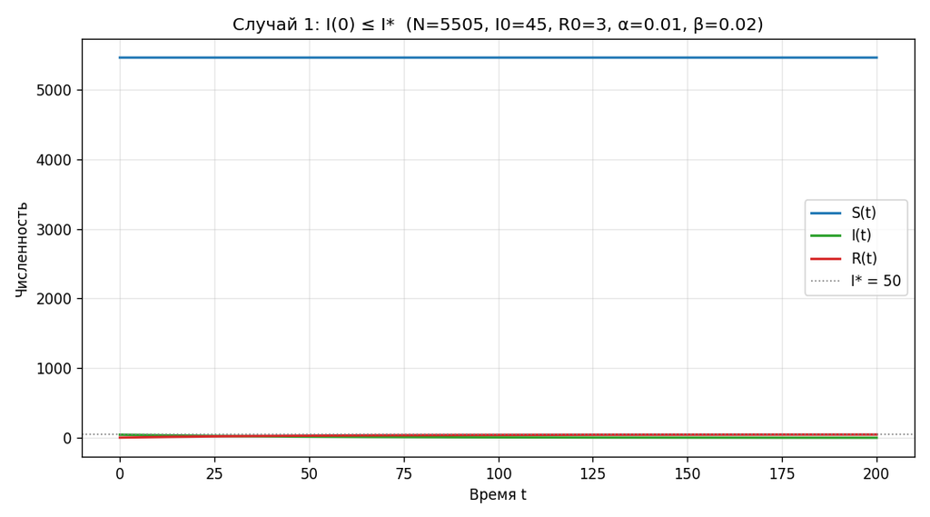

## Случай 1: интерпретация

- $S(t) = S(0) = 5457$ — восприимчивые не меняются
- $I(t) = 45 \cdot e^{-\beta t}$ — экспоненциальное убывание
- $R(t) \to R(0) + I(0) \approx 48$ — все переходят в иммунную группу
- **Эпидемия не разгорается**

## Случай 2: $I(0) > I^{*}$

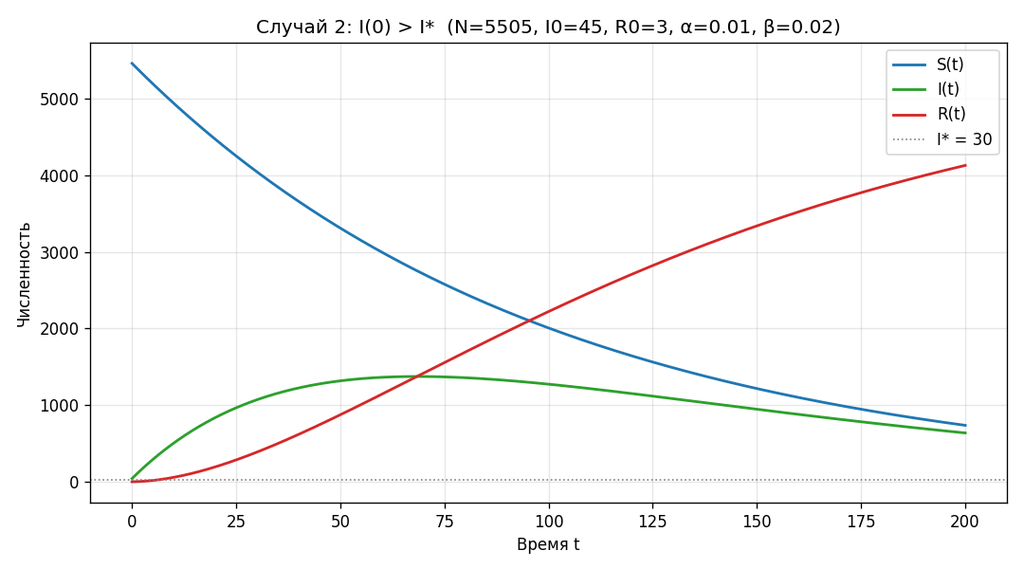

## Случай 2: интерпретация

- $S(t)$ монотонно убывает по экспоненте
- $I(t)$ растёт, достигает максимума $\approx 1376$ при $t \approx 70$
- $R(t)$ монотонно растёт до $\approx 4127$ ($\approx 75\,\%$ населения)
- **Классическая эпидемическая волна**

## Сравнение двух случаев

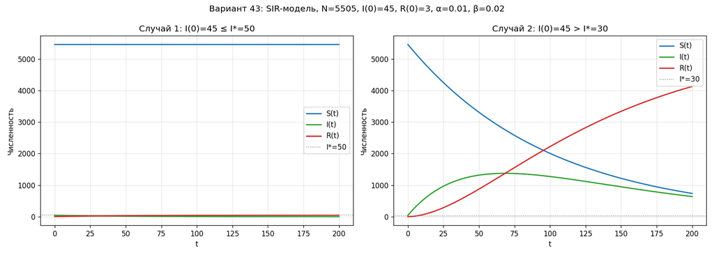

## Динамика $I(t)$

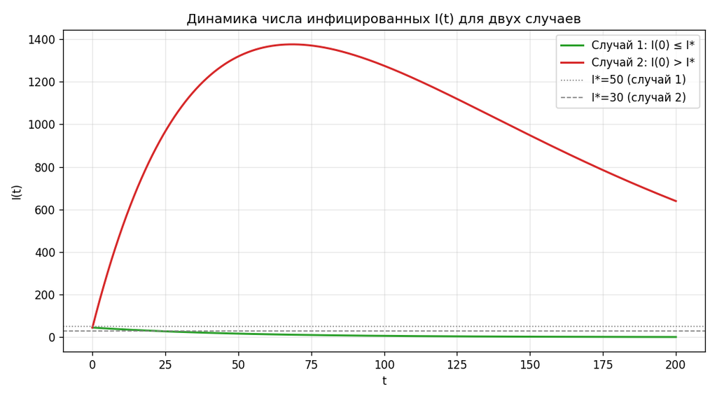

# Итоги

## Выводы

- Реализована SIR-модель с пороговым параметром $I^{*}$
- Численно решена система ОДУ методом Tsit5
- При $I(0) \le I^{*}$ эпидемия блокируется механизмом изоляции
- При $I(0) > I^{*}$ возникает эпидемическая волна
- Порог $I^{*}$ — критический параметр, отделяющий два режима

## Заключительный слайд

- Простейшая SIR-модель воспроизводит ключевую качественную картину эпидемических процессов
- Изоляция больных при $I \le I^{*}$ полностью предотвращает распространение
- При нарушении порога эпидемия охватывает большую часть популяции